# Regresiones Lineales - Ejemplo Calificadoras

### Funciones Útiles

```r
prob<-function(x){
  out<-min(length(x[x>0])/length(x),length(x[x<0])/length(x))
  out
}
```

### Leemos los datos de un archivo txt

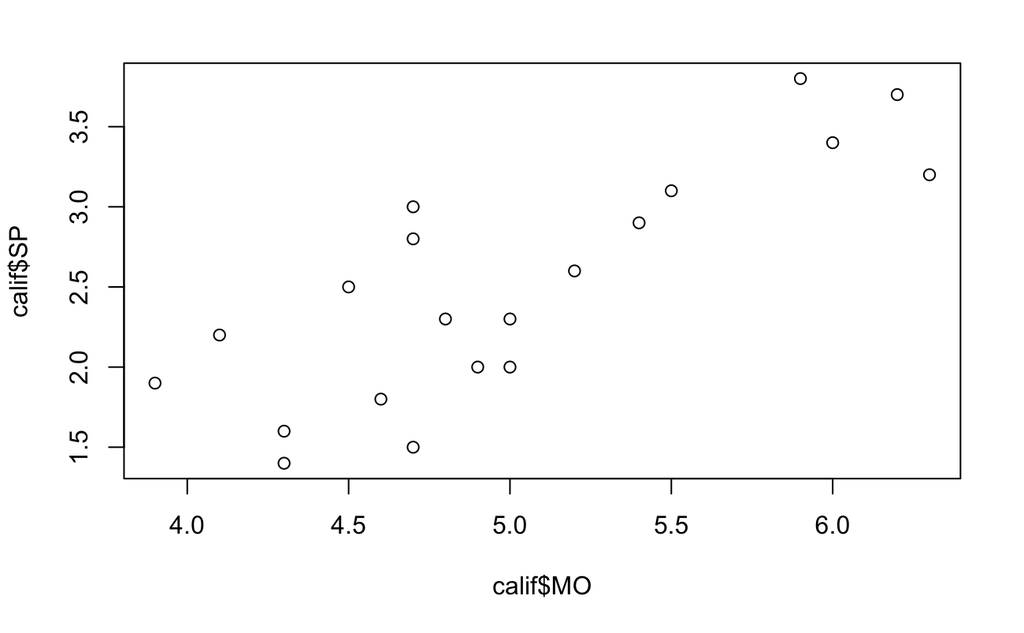

```r
#--- Ejemplo 3 ---
#-Reading data-
calif<-read.table("http://allman.rhon.itam.mx/~lnieto/index_archivos/calificaciones.txt",header=TRUE)
n<-nrow(calif)
plot(calif$MO, calif$SP)
```

### Defining data - siempre como lista para JAGS

```r
data<-list("n"=n,"y"=calif$SP,"x"=calif$MO)
```

### Defining inits

```r
inits<-function(){list(beta=rep(0,2),tau=1,yf=rep(0,n))}
```

### Defining parametros a monitorear

```r
parameters<-c("beta","tau","yf")
```

### Ejecutamos la simulacion

```r
ej3.sim<-jags(data,inits,parameters,model.file="Ej3_a.txt",
              n.iter=100000,n.chains=1,n.burnin=10000,n.thin=1)
```

### Monitoreamos la cadena

#### Cadena

```r
out<-ej3.sim$BUGSoutput$sims.list
# Guardo los valores de Beta2 en Z: Beta2 son los coeficientes asociados a las x2 que es la pendiente
z<-out$beta[,2]
# Defino 4 zonas de ploteo
par(mfrow=c(2,2))
plot(z,type="l")
plot(cumsum(z)/(1:length(z)),type="l")
```

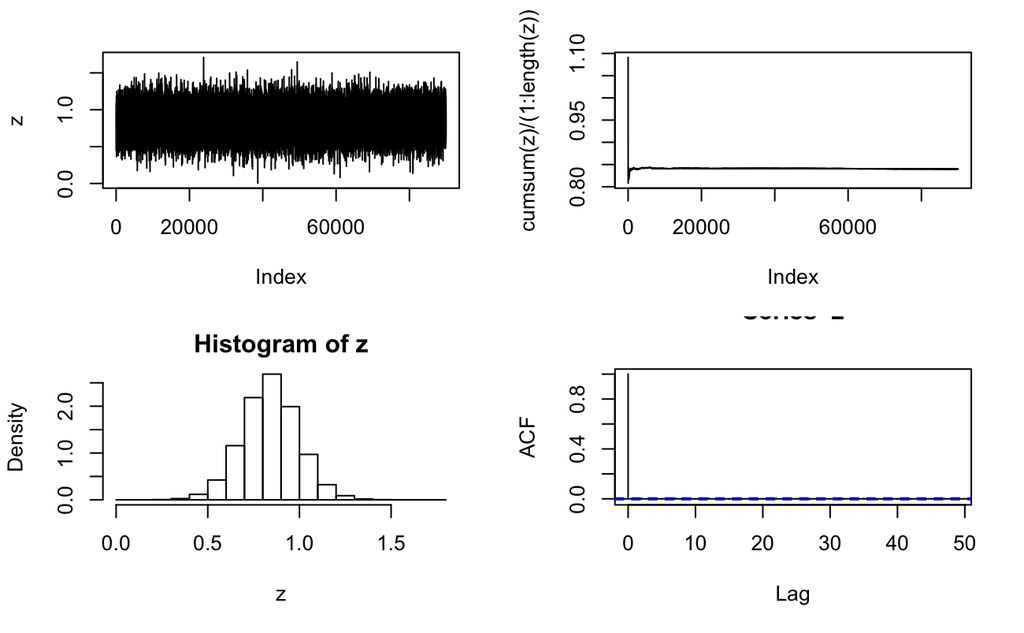

```r
hist(z,freq=FALSE)
acf(z)
```

### En la distribucion final de Beta2, la pendiente en este modelo, cercana a 0.9. Estoy alejada del cero, entonces mi coeficiente de la pendiente es significativamente distinta de cero. Mi histograma no tiene huecos, por lo tanto esta es una muestra de la distribucion que puedo tomar para hacer inferencias

### Hago lo mismo para Bet1, la ordenada al origen

```r
z<-out$beta[,1]
# Defino 4 zonas de ploteo
par(mfrow=c(2,2))
plot(z,type="l")
plot(cumsum(z)/(1:length(z)),type="l")
```

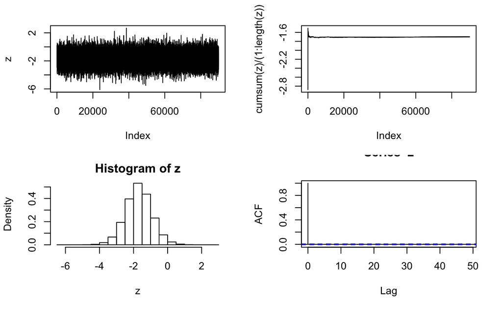

```r
hist(z,freq=FALSE)
acf(z)
```

### Beta1, toma valores alrededor de -2, esta mordiendo un poquito el cero.

### Correlacion entre Beta1 y Beta2

```r
z<-out$beta
# Defino 1 zona de ploteo
par(mfrom=c(1,1))
```

```
"mfrom" is not a graphical parameter
```

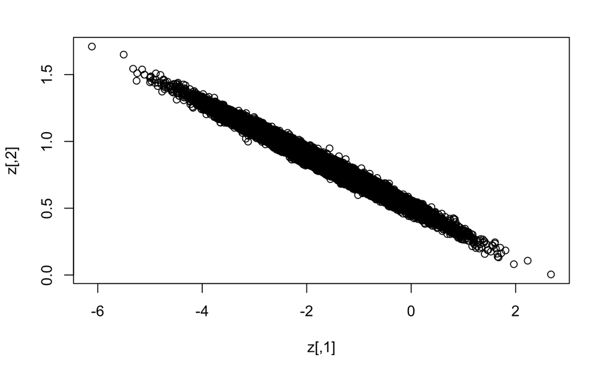

```r
plot(z)
```

### Resumen de estimadores

```r
out.sum<-ej3.sim$BUGSoutput$summary
print(out.sum)
```

```
               mean        sd       2.5%        25%        50%        75%     97.5%
beta[1]  -1.6986255 0.7721202 -3.2280235 -2.1979182 -1.7011398 -1.1976261 -0.160504
beta[2]   0.8397974 0.1529692  0.5354234  0.7407978  0.8401013  0.9388507  1.142425
deviance 24.5992752 2.6514854 21.5845910 22.6615308 23.9113482 25.8110721 31.520803
tau       5.2725125 1.7563327  2.4190464  4.0036112  5.0779422  6.3345089  9.237149
yf[1]     2.9214352 0.4800059  1.9614180  2.6111175  2.9202214  3.2332999  3.869860
yf[2]     2.3316192 0.4744847  1.3913911  2.0242664  2.3324692  2.6377611  3.265404
yf[3]     2.2481625 0.4738858  1.3059598  1.9394595  2.2491492  2.5562205  3.183443
yf[4]     1.5747716 0.5022262  0.5822374  1.2485122  1.5756563  1.9006080  2.568362
yf[5]     2.0808211 0.4781046  1.1312408  1.7714504  2.0785437  2.3898769  3.030765
yf[6]     3.5058816 0.5068674  2.4955321  3.1774605  3.5066494  3.8368744  4.506656
yf[7]     3.3399678 0.4994002  2.3485023  3.0155117  3.3380162  3.6640902  4.331539
yf[8]     2.6677871 0.4725993  1.7371633  2.3585171  2.6678982  2.9735802  3.604090
yf[9]     2.2491891 0.4762520  1.3019813  1.9422462  2.2517418  2.5577381  3.192069
yf[10]    1.9113253 0.4845551  0.9471327  1.5983720  1.9117799  2.2281136  2.868194
yf[11]    2.4164906 0.4755747  1.4747923  2.1081313  2.4171137  2.7260219  3.355708
yf[12]    2.8358411 0.4789055  1.8826524  2.5256269  2.8350930  3.1457138  3.789674
yf[13]    2.5004415 0.4744091  1.5642761  2.1939562  2.4981145  2.8066545  3.438123
yf[14]    3.5925963 0.5128738  2.5815023  3.2575500  3.5930675  3.9271355  4.602429
yf[15]    2.1639071 0.4791419  1.2183263  1.8543630  2.1635986  2.4742319  3.116483
yf[16]    1.9145696 0.4842865  0.9517102  1.6017805  1.9159125  2.2291865  2.877141
yf[17]    2.4988387 0.4713088  1.5609174  2.1934479  2.5000398  2.8060927  3.430816
yf[18]    3.2540885 0.4937600  2.2731021  2.9349933  3.2547837  3.5739842  4.231307
yf[19]    1.7450795 0.4932285  0.7631524  1.4247884  1.7464244  2.0647897  2.723031
yf[20]    2.2480262 0.4759987  1.3080535  1.9397734  2.2484243  2.5555911  3.191413
```

```r
head(out.sum)
```

```
               mean        sd       2.5%        25%        50%        75%     97.5%
beta[1]  -1.6986255 0.7721202 -3.2280235 -2.1979182 -1.7011398 -1.1976261 -0.160504
beta[2]   0.8397974 0.1529692  0.5354234  0.7407978  0.8401013  0.9388507  1.142425
deviance 24.5992752 2.6514854 21.5845910 22.6615308 23.9113482 25.8110721 31.520803
tau       5.2725125 1.7563327  2.4190464  4.0036112  5.0779422  6.3345089  9.237149
yf[1]     2.9214352 0.4800059  1.9614180  2.6111175  2.9202214  3.2332999  3.869860
yf[2]     2.3316192 0.4744847  1.3913911  2.0242664  2.3324692  2.6377611  3.265404
```

### Si quiero estimar de manera puntual Beta1: esta alrededor de -1.69 con un desvío de 0.76. Beta 2: alrededor de 0.83 con un desvio de 0.15.Como esta es la media, es la funcion de pérdida cuadrática la que estoy usando para mi función de pérdida.

### Lo que mas me va a importar son los intervalos de estimacion de credibilidad del 95%:

### Beta1 [ -3.20 - -0.17]

### Beta2 [ 0.53 - 1.14]

### Existe otro indicador que me es más útil para tomar la decisión de si un coeficiente está cercano a cero o no. La probabilidad de que Beta1 sea menor a cero?. Y esta es la distribución final

### Probabilidades

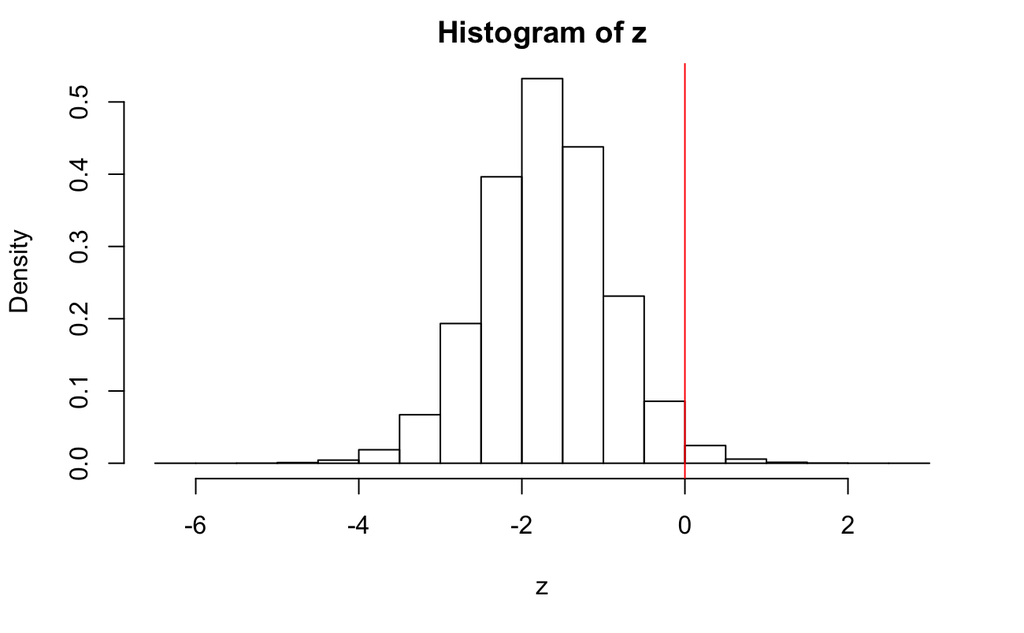

```r
z<-out$beta[,1]
hist(z,freq=FALSE)
abline(v=0,col=2)
```

```r
1 - prob(z)
```

```
[1] 0.9840889
```

### La probabilidad de que Beta1 sea menor a cero es 0.98, 98%, es mas que el 95% que vimos en los intervalos. Entonces mi coeficiente Beta1 es significativamente distinto de cero. La proba es chiquita lo tomo, asi es como se interpreta mi valor “p”.

### DIC

```r
out.dic<-ej3.sim$BUGSoutput$DIC
print(out.dic)
```

```
[1] 28.11446
```

### Siempre es importante escalar los datos si están en escalas muy chicas o muy grandes para resolver problemas numéricos.

### Predicciones: el vector out.sum contiene todas las predicciones y quiero filtrar solo las yf para poder graficarlas

```r
out.yf1<-out.sum[grep("yf",rownames(out.sum)),]
or<-order(calif$MO)
ymin<-min(calif$SP,out.yf1[,c(1,3,7)])
ymax<-max(calif$SP,out.yf1[,c(1,3,7)])
par(mfrow=c(1,1))
plot(calif$MO,calif$SP,ylim=c(ymin,ymax))
lines(calif$MO[or],out.yf1[or,1],lwd=2,col=2)
```

```r
lines(calif$MO[or],out.yf1[or,3],lty=2,col=2)
lines(calif$MO[or],out.yf1[or,7],lty=2,col=2)
```

```r
lines(calif$MO[or],out.yf2[or,1],lwd=2,col=5)
lines(calif$MO[or],out.yf2[or,3],lty=2,col=5)
```

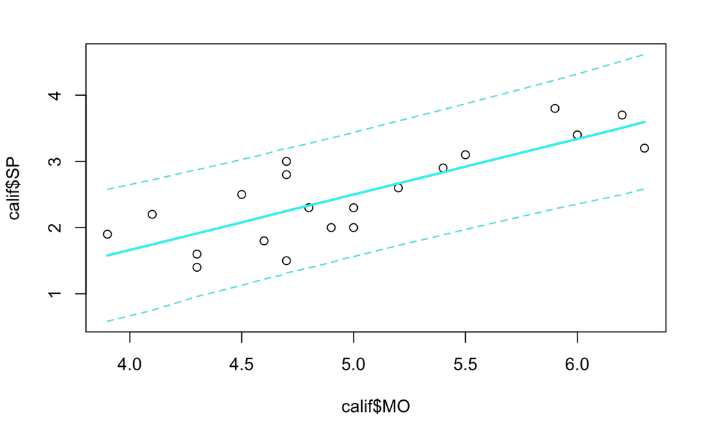

```r
lines(calif$MO[or],out.yf2[or,7],lty=2,col=5)
```

### Aqui tenemos graficados el estimador puntual (raya continua) y nuestros intervalos de predicción (lineas punteadas). Si nuestros intervalos de predicción contienen a los valores estimados, como en este caso todos los puntos están contenidos, entonces mi modelo es bueno.